# Chapter 4: Incidental catch in fisheries

Ignacia Rivera

July 2, 2018

### A Montecarlo approach for estimating the chance of success in an observer program

How likely one is to obtain statistically meaningful data for a given level of observer coverage?

#### Step 1. Estimating k and m from the data

To estimate $m$ and $k$ from the data we consider:

$$E\{C_i\} = m = \frac{1}{N_{last}} \sum c_i$$
$$VAR\{C_i\} = m + \frac{m^2}{k} = \frac{1}{N_{last} - 1} \sum (c_i - m)^2$$

```r
# Importing frequency distribution of by-catch.

data  <- readxl::read_xlsx(here::here("ch_4", "data", "table_4_3.xlsx"), sheet = 1, skip= 2)
colnames(data) <- c("n.birds", "freq")

# Estimating m and k parameters for negative binomial distirbution from the data

data.param <- data %>%
  dplyr::mutate(obsv = n.birds*freq) %>%
  dplyr::summarise(m = sum(obsv)/sum(freq), VAR = sum(((n.birds - m)^2)*freq) / (sum(freq) - 1), k = m^2/(VAR - m))

knitr::kable(data.param)
```

| m | VAR | k |
| --- | --- | --- |
| 0.2787068 | 1.565093 | 0.0603843 |

#### Step 2. Negative binomial distribution for $n$ birds in the by-catch of one tow.

The number of birds present in the by-catch of one tow is decribed by a negative binomial distribution. We will draw a random value from a negative binomial distribution with parameters $m$ and $k$ to determine the number of birds caught in a tow (Figure 1). To do this we first generate a random number from a unifrom distribution and then see where it falls in the cumulative density function of a negative binomial distribution (Figure 2).

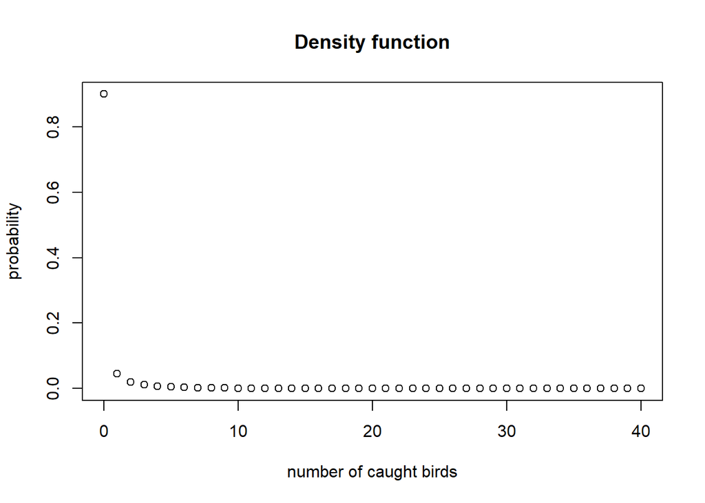

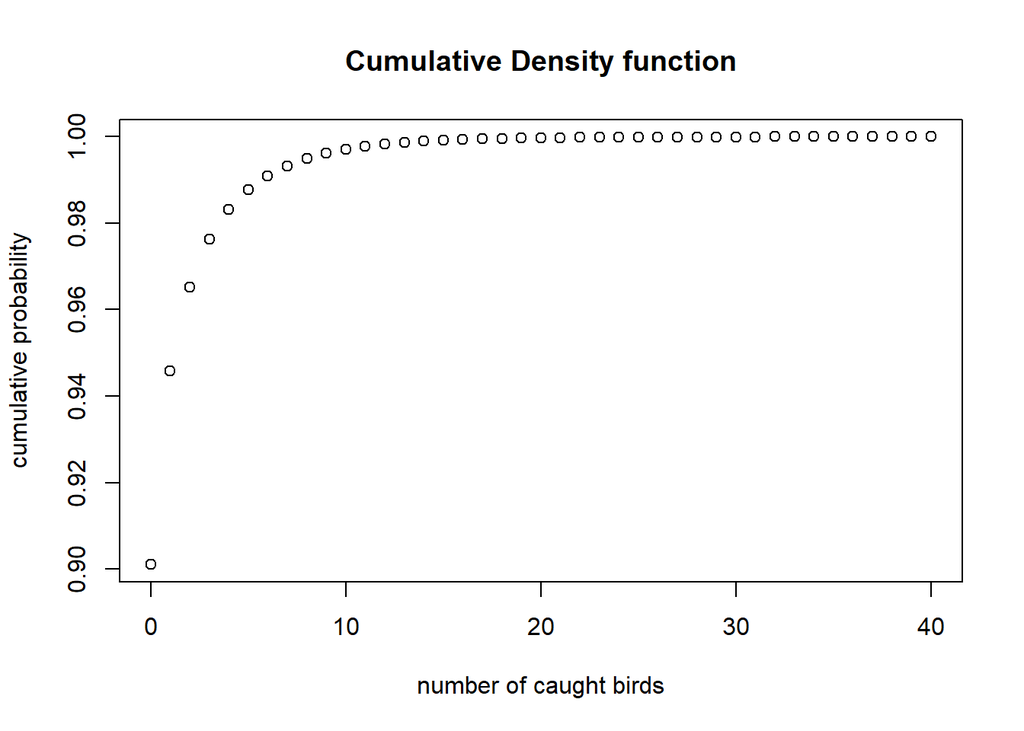

#### Step 3. Simulating $N_{sim}$ of $N_{tow}$ each one and compute number of successes.

This is a function that first, calculates the cumulative probabilities for the $n$ birds in the by-catch based on a negative binomial distribution with parameters $k$ and $m$. Then, runs $N_{sim}$ simulations to estimate the probability of success of $N_{tow}$ tows in gathering statistically meaningfully data based on the confidence level we want (given by $t_q$) and the tolerable error of the mean (given by $d$).

```r
pr.success.n.tows <- function(n, m, k, N.sim, N.tow, tq, d){ #n is a vector

# Generates dataframe with prob of n birds in by-catch, and cumulative probility

pr.n = ((gamma(k+n))/(gamma(k)*factorial(n))) * ((k/(k+m))^k) * (m/(m+k))^n # based on eq. 4.7

prob = data.frame(n.birds = n, pr.n = pr.n, cum.pr.n = cumsum(pr.n)) %>%
    dplyr::mutate(floor.n = dplyr::lag(cum.pr.n, n=1, default = 0))

# Store the mean and the variance of number of birds in the by-catch for each simulation
mean <- rep(NA, N.sim)
var <- rep(NA, N.sim)

for(j in 1:N.sim){

# Stores number of birds in the by-catch for each tow
C.i = rep(NA, N.tow)

 for (i in 1:N.tow){

  u = runif(1) # draws a random number from an uniform distirbution
  n.birds.tow.i = prob$n.birds[which(u > prob$floor.n & u < prob$cum.pr.n)] # test where does u fall in the CDF generated above to fill the number of birds in the ith tow (from Casey's code)

  if(length(n.birds.tow.i) == 0) {
      # If there is no interval in where the draw number falls, we assign the max   number of birds in our vector.
      n.birds.tow.i = max(prob$n.birds) # adapted from Casey's code.
  }

  # store the number of birds caught in each i tow
  C.i[i] = n.birds.tow.i
 }

mean[j] = mean(C.i)
var[j] = var(C.i)

}

# Computes the number of successes (statistically meaningfull data) with N.tows
pr.success <- data.frame(j = seq(1:N.sim), mean= mean, var= var) %>%
  dplyr::mutate(range = 2 * sqrt(var / N.tow) * tq, success= ifelse(range < d*mean, 1, 0)) %>%
  dplyr::summarise(pr.success = sum(success)/N.sim)

pr.success <- as.numeric(pr.success) #transforming data frame to numeric

}
```

#### Step 4. What is the probability of succes for different $N_{tow}$?.

Using the function above we calculate the prbability of success for different number of tows by iterating over $N_{tow}$.

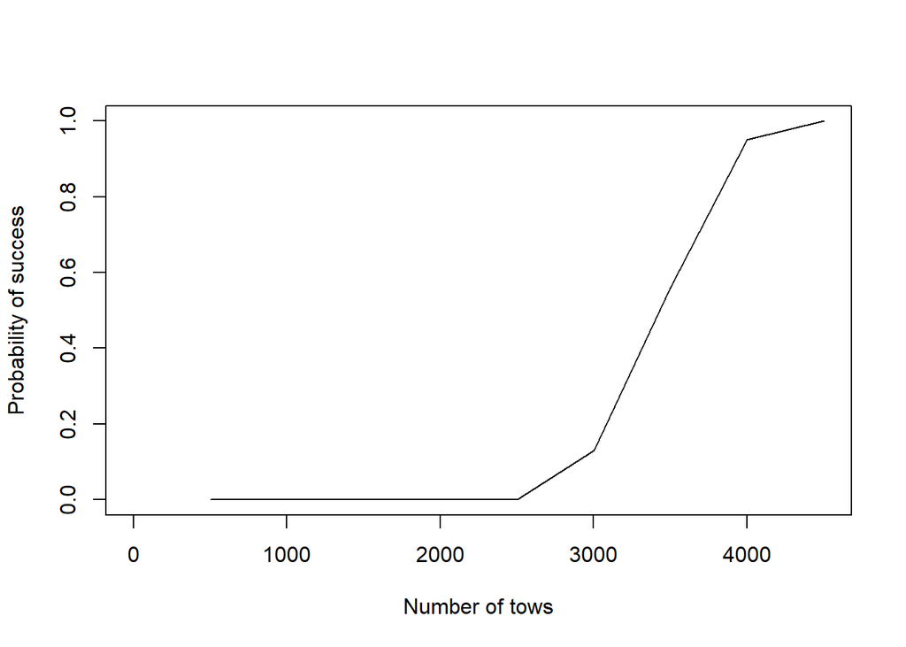

```r
# Setting parameters

seq.tows <- c(seq(from= 1, to= 5000, by= 500))

pr.success.n.tows.store <- rep(NA, length(seq.tows))

for (k in 1:length(seq.tows)){

pr.success.n.tows.store[k] <- pr.success.n.tows(n = c(seq(from=0, to =40, by=1)), m = data.param$m, k = data.param$k, N.sim = 100, N.tow = seq.tows[k],  tq = 1.645, d = 0.25)

}

pr.success.n.tows.dta <- data.frame(seq.tows, pr.success.n.tows.store)

plot(seq.tows, pr.success.n.tows.store, type= 'l', ylab= 'Probability of success', xlab = 'Number of tows')
```